# Entregable 4: Normalización, Expresión Diferencial y Análisis Funcional

Equipo 4 - Leonardo Ivan Anaya Gonzalez & Rubií Martínez Chavarría

2026-05-25

## Descripción del equipo

- **Equipo:** Equipo 4
- **Integrantes:**
  - Leonardo Ivan Anaya Gonzalez (lanaya)
  - Rubií Martínez Chavarría (rmartinez)
- **Correos electrónicos:** leoianayaglz@gmail.com | rubimarch201@gmail.com

## Contexto

Este entregable continúa a partir del Entregable 3, donde se realizó el control de calidad con FastQC/MultiQC, la eliminación de adaptadores con Trimmomatic, el pseudoalineamiento con **Kallisto** y el alineamiento con **STAR**, seguidos de la importación de datos en R mediante `tximport`. Los objetos `dds` (Kallisto) y `dds_star` (STAR) fueron construidos con DESeq2, filtrados (≥10 cuentas en ≥3 muestras) y con diseño `~ genotype` (referencia: WT).

En este entregable realizamos:

1. Normalización de cuentas (rlog, z-score, melted counts)
2. Análisis exploratorio de componentes principales (PCA) y corrección de batch effect
3. Análisis de expresión diferencial con DESeq2 y shrinkage de log2FC
4. Visualización: volcano, MA plot, heatmap
5. Comparación Kallisto vs STAR
6. Análisis funcional de términos GO con gprofiler2

## 0. Cargar paquetes

```r
library(DESeq2)        # Normalización y análisis de expresión diferencial
library(tximport)      # Importar datos de Kallisto
library(rhdf5)         # Leer archivos .h5 de Kallisto
library(ggplot2)       # Visualización
library(dplyr)         # Manipulación de datos
library(reshape2)      # Conversión wide → long (melt)
library(pheatmap)      # Heatmaps
library(RColorBrewer)  # Paletas de colores
library(knitr)         # Tablas en el documento
library(kableExtra)    # Formato de tablas
library(ggrepel)       # Etiquetas sin superposición
library(gprofiler2)    # Análisis de enriquecimiento funcional
library(VennDiagram)   # Diagramas de Venn
library(grid)          # Para dibujar Venn
library(limma)         # Corrección de batch effect
library(apeglm)        # Prior para lfcShrink
```

## 1. Cargar datos y reconstruir objetos DESeq2

```r
# Rutas
ruta_kallisto <- "/Users/dubsirubs/Desktop/RNAseq_Equipo4/results_final/kallisto"
star_dir      <- "/Users/dubsirubs/Desktop/RNAseq_Equipo4/results_final/STAR"
outdir        <- "/Users/dubsirubs/Desktop/RNAseq_Equipo4/results_final/"
figdir        <- "/Users/dubsirubs/Desktop/RNAseq_Equipo4/results_final/figures/"

samples <- c("SRR33445252","SRR33445253","SRR33445254",
             "SRR33445260","SRR33445261","SRR33445262")

# Metadata
metadata <- read.csv("/Users/dubsirubs/Desktop/RNAseq_Equipo4/metadata.csv")
metadata$genotype <- factor(metadata$genotype, levels = c("WT", "Dp16"))
rownames(metadata) <- metadata$sample

# Kallisto → tximport → DESeq2
archivos_h5 <- file.path(ruta_kallisto, samples, "abundance.h5")
names(archivos_h5) <- samples

tx2gene <- read.csv("/Users/dubsirubs/Desktop/RNAseq_Equipo4/results_final/tx2gene_kallisto.csv")

txi.kallisto <- tximport(archivos_h5,
                         type            = "kallisto",
                         tx2gene         = tx2gene,
                         txOut           = FALSE,
                         ignoreTxVersion = FALSE,
                         ignoreAfterBar  = TRUE)

dds <- DESeqDataSetFromTximport(txi.kallisto,
                                colData = metadata,
                                design  = ~ genotype)
# Filtro: genes con ≥10 cuentas en al menos 3 muestras
keep <- rowSums(counts(dds) >= 10) >= 3
dds  <- dds[keep, ]

# STAR → DESeq2
count_list  <- lapply(samples, function(s) {
  f <- file.path(star_dir, s, paste0(s, ".ReadsPerGene.out.tab"))
  read.table(f, skip = 4, header = FALSE)[, c(1, 2)]
})
counts_star <- do.call(cbind, lapply(count_list, function(x) x[, 2]))
rownames(counts_star) <- count_list[[1]][, 1]
colnames(counts_star) <- samples

dds_star <- DESeqDataSetFromMatrix(countData = counts_star,
                                   colData   = metadata,
                                   design    = ~ genotype)
keep_star <- rowSums(counts(dds_star) >= 10) >= 3
dds_star  <- dds_star[keep_star, ]

cat("Genes retenidos — Kallisto:", nrow(dds), "| STAR:", nrow(dds_star), "\n")
```

```
## Genes retenidos — Kallisto: 14715 | STAR: 14091
```

## 2. Normalización de las cuentas

Las cuentas crudas de RNA-seq no son comparables entre muestras porque dependen del tamaño total de la librería y, en el caso de Kallisto, también de la longitud de los transcritos. La **rlog (regularized logarithm)** es la transformación recomendada por DESeq2 cuando el número de muestras es pequeño (n < 30), como en este caso con 6 muestras. Aplica un log2 regularizado que encoge los valores de genes con poca información hacia la media global, estabilizando la varianza sin los artefactos que VST puede introducir con datasets pequeños. Los datos resultantes quedan en una escala apta para PCA, heatmaps y clustering. Se usa `blind = FALSE` porque conocemos el diseño experimental, lo que permite que la transformación tome en cuenta el genotipo durante la estimación de la dispersión.

### 2.1 rlog y Kallisto

```r
rld_kallisto <- rlog(dds, blind = FALSE)
cat("Dimensiones rlog Kallisto (genes × muestras):", dim(rld_kallisto), "\n")
```

```
## Dimensiones rlog Kallisto (genes × muestras): 14715 6
```

### 2.2 rlog y STAR

```r
rld_star <- rlog(dds_star, blind = FALSE)
cat("Dimensiones rlog STAR (genes × muestras):", dim(rld_star), "\n")
```

```
## Dimensiones rlog STAR (genes × muestras): 14091 6
```

### 2.3 Distribución de cuentas normalizadas

El boxplot muestra la distribución de los valores rlog por muestra. Si la normalización fue exitosa, las medianas de todas las cajas deben estar al mismo nivel, indicando que las muestras son comparables entre sí independientemente del tamaño de su librería.

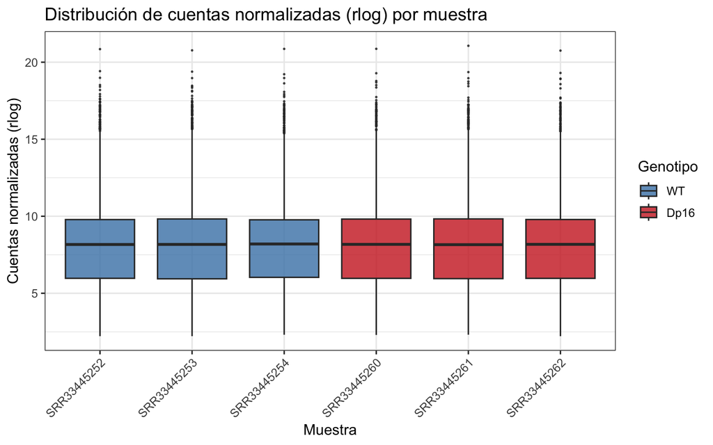

Figura 1. Distribución de cuentas normalizadas (rlog, Kallisto) por muestra. Las medianas alineadas indican que la normalización fue exitosa y las muestras son comparables.

```r
melted_norm_counts <- data.frame(melt(assay(rld_kallisto)))
colnames(melted_norm_counts) <- c("gene", "sample", "normalized_counts")

melted_norm_counts <- left_join(
  melted_norm_counts,
  data.frame(sample = rownames(metadata), genotype = metadata$genotype),
  by = "sample"
)

ggplot(melted_norm_counts,
       aes(x = sample, y = normalized_counts, fill = genotype)) +
  geom_boxplot(outlier.size = 0.3, alpha = 0.8) +
  scale_fill_manual(values = c("WT" = "steelblue", "Dp16" = "firebrick3")) +
  labs(title = "Distribución de cuentas normalizadas (rlog) por muestra",
       x = "Muestra", y = "Cuentas normalizadas (rlog)", fill = "Genotipo") +
  theme_bw(base_size = 12) +
  theme(axis.text.x = element_text(angle = 45, hjust = 1),
        plot.background = element_rect(fill = "white"))
```

### 2.4 Z-score

El z-score estandariza cada gen a media = 0 y desviación estándar = 1 a través de todas las muestras. Esto elimina las diferencias de escala absoluta entre genes (algunos tienen expresión basalmente alta y otros baja) y resalta los patrones de expresión relativa, lo que facilita el clustering y la visualización en heatmaps. Se aplica `t(scale(t(x)))` porque `scale()` opera por columnas — al transponer dos veces, escalamos por filas (por gen).

```r
counts_raw <- counts(dds)

# Eliminar genes con varianza = 0 (misma expresión en todas las muestras)
var_non_zero    <- apply(counts_raw, 1, var) != 0
filtered_counts <- counts_raw[var_non_zero, ]

# t(scale(t(x))): transponer → escalar por gen → transponer de vuelta
zscores    <- t(scale(t(filtered_counts)))
zscore_mat <- as.matrix(zscores)

cat("Genes con varianza > 0:", nrow(zscore_mat), "\n")
```

```
## Genes con varianza > 0: 14715
```

```r
cat("Muestras:", ncol(zscore_mat), "\n")
```

```
## Muestras: 6
```

## 3. Análisis exploratorio: PCA

El PCA reduce la dimensionalidad de los datos (miles de genes) a componentes que capturan la mayor variación. Su propósito es verificar que las muestras agrupan por la variable biológica de interés (genotipo) y no por variables técnicas (fecha, técnico, equipo de secuenciación), lo que indicaría un batch effect.

### 3.1 PCA y Kallisto

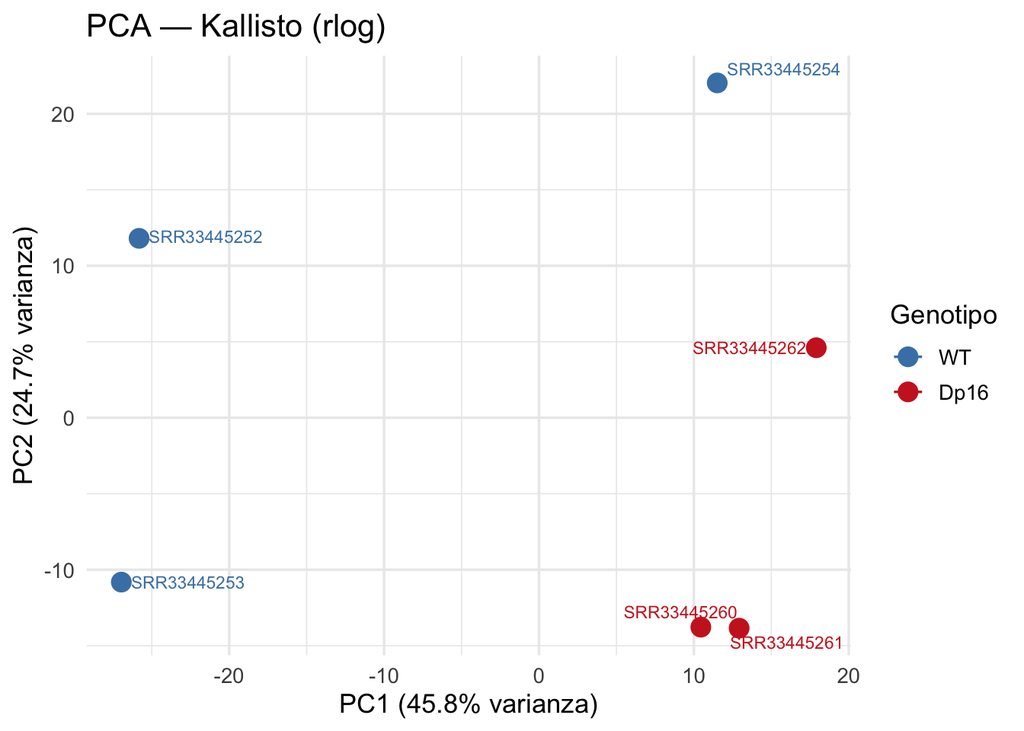

```r
mat_k <- assay(rld_kallisto)
pc_k  <- prcomp(t(mat_k))   # t() porque prcomp espera muestras en filas

var_exp_k <- pc_k$sdev^2 / sum(pc_k$sdev^2) * 100

pca_df_k <- data.frame(
  PC1      = pc_k$x[, 1],
  PC2      = pc_k$x[, 2],
  genotype = metadata$genotype,
  sample   = rownames(metadata)
)

ggplot(pca_df_k, aes(x = PC1, y = PC2, color = genotype, label = sample)) +
  geom_point(size = 4) +
  geom_text_repel(size = 3, show.legend = FALSE) +
  stat_ellipse(aes(group = genotype), linetype = "dashed", level = 0.8) +
  scale_color_manual(values = c("WT" = "steelblue", "Dp16" = "firebrick3")) +
  labs(title = "PCA — Kallisto (rlog)",
       x     = sprintf("PC1 (%.1f%% varianza)", var_exp_k[1]),
       y     = sprintf("PC2 (%.1f%% varianza)", var_exp_k[2]),
       color = "Genotipo") +
  theme_minimal(base_size = 13) +
  theme(plot.background = element_rect(fill = "white"))
```

### 3.2 Scree Plot

El scree plot muestra qué porcentaje de la varianza total captura cada componente principal. Es útil para saber cuántos PCs son informativos: un “codo” pronunciado indica que los primeros PCs concentran la mayor parte de la información.

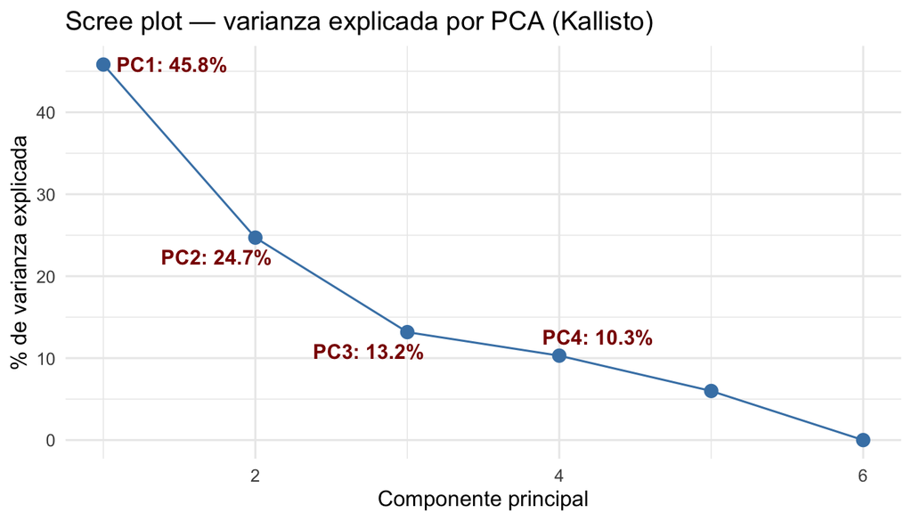

Figura 3. Scree plot: porcentaje de varianza explicada por cada componente principal (Kallisto). Las etiquetas muestran los primeros cuatro componentes.

```r
df_scree <- data.frame(
  Componente = seq_along(var_exp_k),
  Varianza   = var_exp_k,
  Etiqueta   = paste0("PC", seq_along(var_exp_k), ": ",
                      round(var_exp_k, 1), "%")
)

ggplot(df_scree, aes(x = Componente, y = Varianza)) +
  geom_point(color = "steelblue", size = 3) +
  geom_line(color = "steelblue") +
  geom_text_repel(data = df_scree[1:4, ],
                  aes(label = Etiqueta),
                  size = 4, color = "darkred", fontface = "bold",
                  box.padding = 0.4) +
  labs(title = "Scree plot — varianza explicada por PCA (Kallisto)",
       x = "Componente principal",
       y = "% de varianza explicada") +
  theme_minimal(base_size = 12) +
  theme(plot.background = element_rect(fill = "white"))
```

### 3.3 PCA y STAR

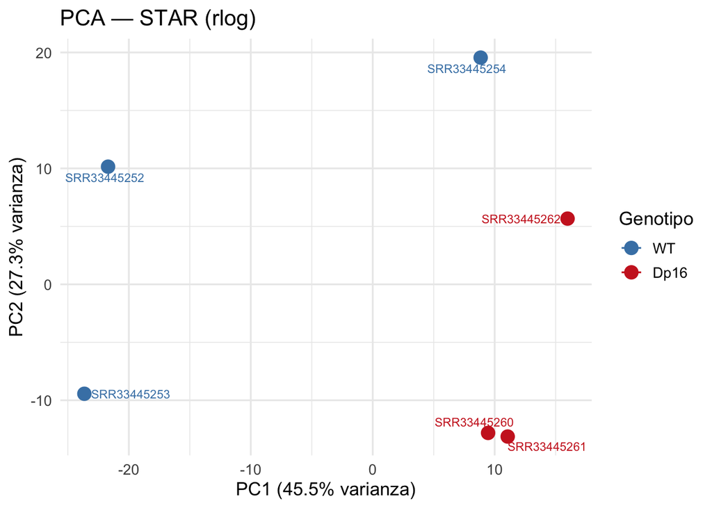

Figura 4. PCA de muestras normalizadas con rlog (STAR). Se esperan los mismos patrones de agrupamiento que en Kallisto si ambos alineadores son concordantes.

```r
mat_s <- assay(rld_star)
pc_s  <- prcomp(t(mat_s))

var_exp_s <- pc_s$sdev^2 / sum(pc_s$sdev^2) * 100

pca_df_s <- data.frame(
  PC1      = pc_s$x[, 1],
  PC2      = pc_s$x[, 2],
  genotype = metadata$genotype,
  sample   = rownames(metadata)
)

ggplot(pca_df_s, aes(x = PC1, y = PC2, color = genotype, label = sample)) +
  geom_point(size = 4) +
  geom_text_repel(size = 3, show.legend = FALSE) +
  stat_ellipse(aes(group = genotype), linetype = "dashed", level = 0.8) +
  scale_color_manual(values = c("WT" = "steelblue", "Dp16" = "firebrick3")) +
  labs(title = "PCA — STAR (rlog)",
       x     = sprintf("PC1 (%.1f%% varianza)", var_exp_s[1]),
       y     = sprintf("PC2 (%.1f%% varianza)", var_exp_s[2]),
       color = "Genotipo") +
  theme_minimal(base_size = 13) +
  theme(plot.background = element_rect(fill = "white"))
```

### 3.4 Corrección de batch effect

Aunque no tenemos un batch effect conocido en este experimento, aplicamos `limma::removeBatchEffect` como buena práctica para visualización. El argumento `design` protege la señal biológica del genotipo durante la corrección: la función solo elimina la variación que **no** está explicada por el genotipo.

> **Nota importante:** Esta corrección es **únicamente para visualización** (PCA y heatmaps). El análisis diferencial con DESeq2 siempre se corre sobre los datos originales sin corregir; si hubiera un batch real, se incluiría como covariable en la fórmula de diseño (`~ batch + genotype`).

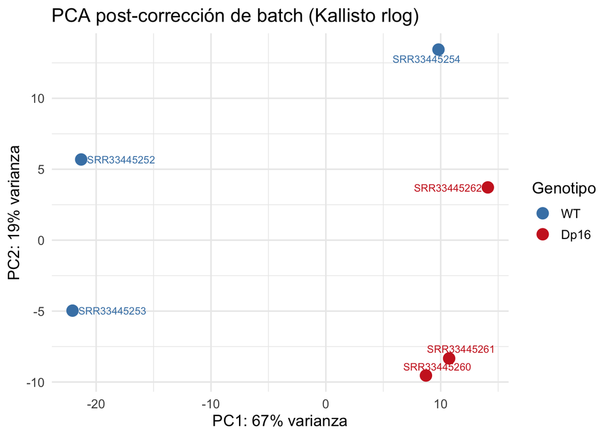

Figura 5. PCA post-corrección de batch effect (Kallisto rlog). Sin batch conocido, la corrección elimina solo la variación residual no explicada por el genotipo, lo que generalmente refuerza la separación entre grupos.

```r
rld_bc    <- rld_kallisto   # copia para no modificar el original
mm_design <- model.matrix(~ genotype, colData(rld_bc))
mat_bc    <- assay(rld_bc)
mat_bc    <- removeBatchEffect(mat_bc, design = mm_design)
assay(rld_bc) <- mat_bc

pcaData_bc    <- plotPCA(rld_bc, intgroup = "genotype", returnData = TRUE)
percentVar_bc <- round(100 * attr(pcaData_bc, "percentVar"))

ggplot(pcaData_bc, aes(PC1, PC2, color = genotype, label = name)) +
  geom_point(size = 4) +
  geom_text_repel(size = 3, show.legend = FALSE) +
  scale_color_manual(values = c("WT" = "steelblue", "Dp16" = "firebrick3")) +
  labs(title = "PCA post-corrección de batch (Kallisto rlog)",
       x = paste0("PC1: ", percentVar_bc[1], "% varianza"),
       y = paste0("PC2: ", percentVar_bc[2], "% varianza"),
       color = "Genotipo") +
  theme_minimal(base_size = 13) +
  theme(plot.background = element_rect(fill = "white"))
```

## 4. Análisis de Expresión Diferencial (DESeq2)

DESeq2 modela las cuentas con una distribución binomial negativa que captura la sobredispersión típica de RNA-seq. El análisis realiza tres pasos: (1) estimación de **factores de tamaño** para corregir diferencias en el total de lecturas, (2) estimación de la **dispersión** gen a gen, y (3) ajuste del modelo lineal generalizado y prueba de Wald para obtener log2FC y p-values.

### 4.1 DESeq2 y Kallisto

```r
# relevel: WT como referencia para que todos los FC se interpreten como "Dp16 vs WT"
dds$genotype <- relevel(dds$genotype, ref = "WT")
dds <- DESeq(dds)
resultsNames(dds)
```

```
## [1] "Intercept"           "genotype_Dp16_vs_WT"
```

```r
res_kallisto <- results(dds,
                        contrast = c("genotype", "Dp16", "WT"),
                        alpha    = 0.05)
summary(res_kallisto)
```

```
##
## out of 14715 with nonzero total read count
## adjusted p-value < 0.05
## LFC > 0 (up)       : 171, 1.2%
## LFC < 0 (down)     : 229, 1.6%
## outliers [1]       : 17, 0.12%
## low counts [2]     : 0, 0%
## (mean count < 5)
## [1] see 'cooksCutoff' argument of ?results
## [2] see 'independentFiltering' argument of ?results
```

### 4.2 Shrinkage de log2FC y Kallisto

Genes con baja expresión o pocas réplicas pueden presentar log2FC muy grandes e inestables, no porque realmente cambien mucho, sino porque hay poca información para estimarlos. El shrinkage con **apeglm** aplica un prior adaptativo que “contrae” esos valores extremos hacia 0, sin modificar los p-values ni el número de genes significativos. El resultado son estimaciones de FC más confiables biológicamente y visualizaciones más limpias.

```r
# coef debe coincidir exactamente con un nombre de resultsNames(dds)
res_kallisto_shrink <- lfcShrink(dds,
                                 coef = "genotype_Dp16_vs_WT",
                                 type = "apeglm")
summary(res_kallisto_shrink)
```

```
##
## out of 14715 with nonzero total read count
## adjusted p-value < 0.1
## LFC > 0 (up)       : 240, 1.6%
## LFC < 0 (down)     : 297, 2%
## outliers [1]       : 17, 0.12%
## low counts [2]     : 0, 0%
## (mean count < 5)
## [1] see 'cooksCutoff' argument of ?results
## [2] see 'independentFiltering' argument of ?results
```

### 4.3 DESeq2 y STAR

```r
dds_star$genotype <- relevel(dds_star$genotype, ref = "WT")
dds_star <- DESeq(dds_star)
resultsNames(dds_star)
```

```
## [1] "Intercept"           "genotype_Dp16_vs_WT"
```

```r
res_star <- results(dds_star,
                    contrast = c("genotype", "Dp16", "WT"),
                    alpha    = 0.05)
summary(res_star)
```

```
##
## out of 14091 with nonzero total read count
## adjusted p-value < 0.05
## LFC > 0 (up)       : 152, 1.1%
## LFC < 0 (down)     : 211, 1.5%
## outliers [1]       : 10, 0.071%
## low counts [2]     : 0, 0%
## (mean count < 5)
## [1] see 'cooksCutoff' argument of ?results
## [2] see 'independentFiltering' argument of ?results
```

```r
res_star_shrink <- lfcShrink(dds_star,
                              coef = "genotype_Dp16_vs_WT",
                              type = "apeglm")
summary(res_star_shrink)
```

```
##
## out of 14091 with nonzero total read count
## adjusted p-value < 0.1
## LFC > 0 (up)       : 237, 1.7%
## LFC < 0 (down)     : 289, 2.1%
## outliers [1]       : 10, 0.071%
## low counts [2]     : 0, 0%
## (mean count < 5)
## [1] see 'cooksCutoff' argument of ?results
## [2] see 'independentFiltering' argument of ?results
```

### 4.4 Tabla comparativa de DEGs

```r
sig_kallisto <- as.data.frame(res_kallisto_shrink) %>%
  filter(!is.na(padj) & padj < 0.05)

sig_star <- as.data.frame(res_star_shrink) %>%
  filter(!is.na(padj) & padj < 0.05)

resumen <- data.frame(
  Alineador      = c("Kallisto", "STAR"),
  Genes_totales  = c(nrow(dds), nrow(dds_star)),
  DEGs_total     = c(nrow(sig_kallisto), nrow(sig_star)),
  Up_regulated   = c(sum(sig_kallisto$log2FoldChange > 0),
                     sum(sig_star$log2FoldChange > 0)),
  Down_regulated = c(sum(sig_kallisto$log2FoldChange < 0),
                     sum(sig_star$log2FoldChange < 0))
)

kable(resumen,
      col.names = c("Alineador", "Genes totales", "DEGs (padj<0.05)",
                    "Up-regulated", "Down-regulated"),
      caption = "Tabla 1. Resumen de genes diferencialmente expresados por alineador (Dp16 vs WT, padj < 0.05).") %>%
  kable_styling(bootstrap_options = c("striped","hover","condensed"),
                full_width = FALSE)
```

Tabla 1. Resumen de genes diferencialmente expresados por alineador (Dp16 vs WT, padj < 0.05).

| Alineador | Genes totales | DEGs (padj<0.05) | Up-regulated | Down-regulated |
| --- | --- | --- | --- | --- |
| Kallisto | 14715 | 400 | 171 | 229 |
| STAR | 14091 | 363 | 152 | 211 |

**Interpretación:** El análisis diferencial identificó 400 DEGs en Kallisto y 363 en STAR (padj < 0.05), con un balance consistente entre pipelines: aproximadamente 57% de los genes están reprimidos en Dp16 respecto a WT y 43% activados. Este patrón sugiere que la trisomía del cromosoma 16 no simplemente incrementa la expresión génica global, sino que genera una reorganización transcriptómica donde la represión domina ligeramente sobre la activación en hígado adulto.

La concordancia entre Kallisto y STAR (~90% en el total de DEGs y balance up/down idéntico) indica que este patrón es robusto e independiente del método de cuantificación. La diferencia en magnitud respecto a los ~1,500 DEGs reportados por Dunn et al. (2026) es atribuible al menor poder estadístico de este análisis (n=3 por genotipo vs n=6 en el paper original); los genes detectados aquí representan los cambios de expresión más robustos y de mayor magnitud del dataset.

## 5. Top genes más significativos

### Top 20 DEGs y Kallisto

```r
top20_k <- sig_kallisto %>%
  arrange(padj) %>%
  head(20) %>%
  select(baseMean, log2FoldChange, lfcSE, pvalue, padj) %>%
  mutate(across(where(is.numeric), ~ round(.x, 4)))

kable(top20_k,
      col.names = c("Expr. media", "log2FC", "SE", "p-value", "p-adj"),
      caption = "Tabla 2. Top 20 genes más significativos — Kallisto (Dp16 vs WT, padj < 0.05). Los genes están ordenados por p-value ajustado de menor a mayor.") %>%
  kable_styling(bootstrap_options = c("striped","hover","condensed"),
                full_width = FALSE)
```

Tabla 2. Top 20 genes más significativos — Kallisto (Dp16 vs WT, padj < 0.05). Los genes están ordenados por p-value ajustado de menor a mayor.

|  | Expr. media | log2FC | SE | p-value | p-adj |
| --- | --- | --- | --- | --- | --- |
| ENSMUSG00000097148.2 | 221.5899 | -3.8684 | 0.4515 | 0 | 0 |
| ENSMUSG00000001665.11 | 2301.2742 | 1.6308 | 0.1995 | 0 | 0 |
| ENSMUSG00000117780.1 | 615.5616 | -3.1112 | 0.3911 | 0 | 0 |
| ENSMUSG00000032080.6 | 13254.4287 | -1.2916 | 0.1689 | 0 | 0 |
| ENSMUSG00000029417.9 | 817.9000 | -1.8694 | 0.2546 | 0 | 0 |
| ENSMUSG00000006494.11 | 3493.7405 | 1.4713 | 0.2022 | 0 | 0 |
| ENSMUSG00000069456.4 | 3868.0862 | 1.3199 | 0.1866 | 0 | 0 |
| ENSMUSG00000094708.1 | 105.7300 | 10.9872 | 3.0280 | 0 | 0 |
| ENSMUSG00000095937.1 | 105.7300 | 10.9872 | 3.0280 | 0 | 0 |
| ENSMUSG00000029822.15 | 127.7477 | -2.3736 | 0.3493 | 0 | 0 |
| ENSMUSG00000057074.6 | 6673.3986 | 1.0001 | 0.1484 | 0 | 0 |
| ENSMUSG00000078606.8 | 488.7620 | -1.4457 | 0.2314 | 0 | 0 |
| ENSMUSG00000027596.10 | 39.5124 | -9.6737 | 2.9575 | 0 | 0 |
| ENSMUSG00000037827.5 | 45.5567 | 9.5875 | 2.8760 | 0 | 0 |
| ENSMUSG00000095597.2 | 40.6972 | 9.4140 | 2.8425 | 0 | 0 |
| ENSMUSG00000024899.7 | 9075.8872 | 0.8624 | 0.1441 | 0 | 0 |
| ENSMUSG00000078922.9 | 427.4633 | -2.1887 | 0.3718 | 0 | 0 |
| ENSMUSG00000074240.5 | 144.8147 | -4.3150 | 0.7433 | 0 | 0 |
| ENSMUSG00000090381.2 | 41.3654 | -5.4125 | 0.9232 | 0 | 0 |
| ENSMUSG00000063590.3 | 94.0080 | -4.3512 | 0.7631 | 0 | 0 |

### Top 20 DEGs y STAR

```r
top20_s <- sig_star %>%
  arrange(padj) %>%
  head(20) %>%
  select(baseMean, log2FoldChange, lfcSE, pvalue, padj) %>%
  mutate(across(where(is.numeric), ~ round(.x, 4)))

kable(top20_s,
      col.names = c("Expr. media", "log2FC", "SE", "p-value", "p-adj"),
      caption = "Tabla 3. Top 20 genes más significativos — STAR (Dp16 vs WT, padj < 0.05). Los genes están ordenados por p-value ajustado de menor a mayor.") %>%
  kable_styling(bootstrap_options = c("striped","hover","condensed"),
                full_width = FALSE)
```

Tabla 3. Top 20 genes más significativos — STAR (Dp16 vs WT, padj < 0.05). Los genes están ordenados por p-value ajustado de menor a mayor.

|  | Expr. media | log2FC | SE | p-value | p-adj |
| --- | --- | --- | --- | --- | --- |
| ENSMUSG00000117780.1 | 624.4800 | -3.3229 | 0.3469 | 0 | 0 |
| ENSMUSG00000029417.9 | 772.7797 | -1.8147 | 0.1940 | 0 | 0 |
| ENSMUSG00000097148.2 | 186.4670 | -3.8658 | 0.4495 | 0 | 0 |
| ENSMUSG00000001665.11 | 1001.2573 | 1.5612 | 0.1837 | 0 | 0 |
| ENSMUSG00000069456.4 | 3676.6815 | 1.3136 | 0.1731 | 0 | 0 |
| ENSMUSG00000057074.6 | 6515.7780 | 1.0052 | 0.1393 | 0 | 0 |
| ENSMUSG00000032080.6 | 2017.0016 | -1.2743 | 0.1793 | 0 | 0 |
| ENSMUSG00000024411.11 | 72.6810 | -2.6860 | 0.4011 | 0 | 0 |
| ENSMUSG00000021416.11 | 57.1663 | 5.8161 | 0.8390 | 0 | 0 |
| ENSMUSG00000015090.13 | 61.9050 | 3.7672 | 0.5926 | 0 | 0 |
| ENSMUSG00000040938.16 | 392.8636 | 1.3553 | 0.2179 | 0 | 0 |
| ENSMUSG00000056131.13 | 325.1514 | -1.3199 | 0.2152 | 0 | 0 |
| ENSMUSG00000023057.5 | 858.5779 | -0.9842 | 0.1614 | 0 | 0 |
| ENSMUSG00000020926.16 | 202.3003 | 2.4592 | 0.4055 | 0 | 0 |
| ENSMUSG00000028359.4 | 228.2812 | 2.3011 | 0.3817 | 0 | 0 |
| ENSMUSG00000034220.7 | 244.6405 | -2.5862 | 0.4312 | 0 | 0 |
| ENSMUSG00000074240.5 | 149.4177 | -4.2809 | 0.7191 | 0 | 0 |
| ENSMUSG00000024899.7 | 9192.1437 | 0.8076 | 0.1360 | 0 | 0 |
| ENSMUSG00000078922.9 | 151.4595 | -1.9564 | 0.3323 | 0 | 0 |
| ENSMUSG00000027596.10 | 28.4416 | -9.1148 | 2.8936 | 0 | 0 |

**Interpretación de las tablas:** `baseMean` es la expresión promedio del gen en todas las muestras (a mayor baseMean, más abundante es el transcrito). `log2FoldChange` indica la dirección y magnitud del cambio en Dp16 respecto a WT: un valor positivo significa que el gen está más expresado en Dp16, negativo que está menos expresado. `lfcSE` es el error estándar del FC después del shrinkage. El `padj` es el p-value corregido por el método de Benjamini-Hochberg para controlar la tasa de falsos positivos.

## 6. Visualización de resultados

### 6.1 Volcano Plot y Kallisto

El volcano plot enfrenta la magnitud del cambio (`log2FC`, eje X) contra la significancia estadística (`-log10(padj)`, eje Y). Los genes biológicamente más relevantes se encuentran en las esquinas superiores: alto FC y muy significativos. Las líneas discontinuas marcan los umbrales de corte: |log2FC| > 1 (cambio de al menos 2 veces) y padj < 0.05.

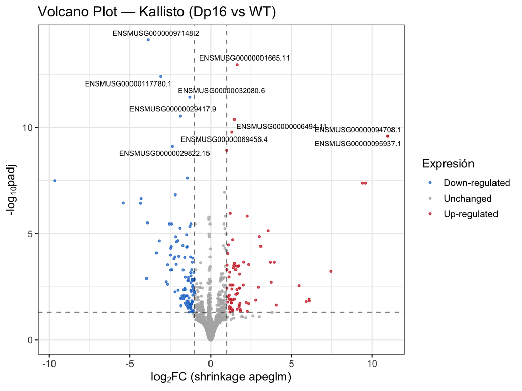

Figura 6. Volcano plot — Kallisto (Dp16 vs WT). Rojo: genes up-regulated en Dp16 (log2FC > 1, padj < 0.05). Azul: genes down-regulated (log2FC < -1, padj < 0.05). Gris: sin cambio significativo. Las etiquetas corresponden a los 10 genes con menor padj.

```r
df_k <- as.data.frame(res_kallisto_shrink) %>%
  mutate(
    gene       = rownames(.),
    Expression = case_when(
      log2FoldChange >= 1  & padj < 0.05 ~ "Up-regulated",
      log2FoldChange <= -1 & padj < 0.05 ~ "Down-regulated",
      TRUE ~ "Unchanged"
    )
  )

top_labels_k <- df_k %>%
  filter(Expression != "Unchanged") %>%
  arrange(padj) %>%
  head(10)

ggplot(df_k, aes(x = log2FoldChange, y = -log10(padj))) +
  geom_point(aes(color = Expression), size = 0.8, alpha = 0.7) +
  geom_text_repel(data = top_labels_k, aes(label = gene),
                  size = 2.8, max.overlaps = 15, show.legend = FALSE) +
  scale_color_manual(values = c("Up-regulated"   = "firebrick3",
                                "Down-regulated" = "dodgerblue3",
                                "Unchanged"      = "gray70")) +
  geom_vline(xintercept = c(-1, 1), linetype = "dashed", alpha = 0.5) +
  geom_hline(yintercept = -log10(0.05), linetype = "dashed", alpha = 0.5) +
  labs(title = "Volcano Plot — Kallisto (Dp16 vs WT)",
       x     = expression("log"[2]*"FC (shrinkage apeglm)"),
       y     = expression("-log"[10]*"padj"),
       color = "Expresión") +
  theme_bw(base_size = 13) +
  theme(plot.background = element_rect(fill = "white"))
```

**Interpretación:** Los genes más significativos y con mayor cambio se concentran en ambas esquinas superiores, confirmando una respuesta transcriptómica clara en Dp16. Los genes etiquetados con mayor significancia en down-regulated (ENSMUSG00000097148.2, ENSMUSG00000117780.1) tienen log2FC entre -3 y -4, indicando una reducción de expresión de 8 a 16 veces respecto a WT. En up-regulated, ENSMUSG00000001665.11 destaca con alta significancia y log2FC ~1.6.El shrinkage es evidente: la nube gris está comprimida cerca de log2FC = 0, y los genes de baja expresión no dominan la gráfica.

### 6.2 Volcano Plot y STAR

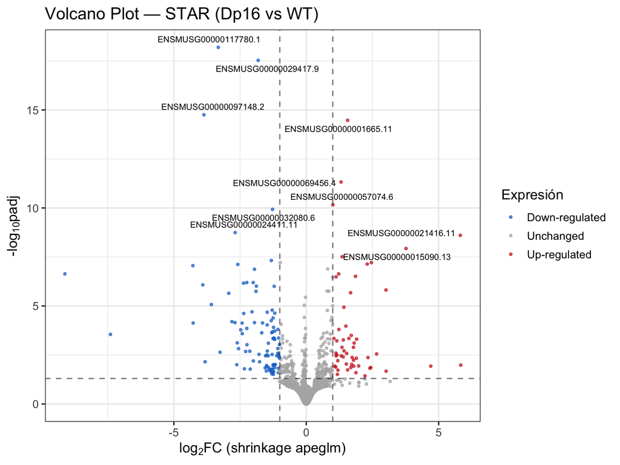

Figura 7. Volcano plot — STAR (Dp16 vs WT). Mismos criterios de corte que Kallisto (|log2FC| > 1, padj < 0.05). La comparación visual entre ambos volcano plots permite evaluar la concordancia entre alineadores.

```r
df_s <- as.data.frame(res_star_shrink) %>%
  mutate(
    gene       = rownames(.),
    Expression = case_when(
      log2FoldChange >= 1  & padj < 0.05 ~ "Up-regulated",
      log2FoldChange <= -1 & padj < 0.05 ~ "Down-regulated",
      TRUE ~ "Unchanged"
    )
  )

top_labels_s <- df_s %>%
  filter(Expression != "Unchanged") %>%
  arrange(padj) %>%
  head(10)

ggplot(df_s, aes(x = log2FoldChange, y = -log10(padj))) +
  geom_point(aes(color = Expression), size = 0.8, alpha = 0.7) +
  geom_text_repel(data = top_labels_s, aes(label = gene),
                  size = 2.8, max.overlaps = 15, show.legend = FALSE) +
  scale_color_manual(values = c("Up-regulated"   = "firebrick3",
                                "Down-regulated" = "dodgerblue3",
                                "Unchanged"      = "gray70")) +
  geom_vline(xintercept = c(-1, 1), linetype = "dashed", alpha = 0.5) +
  geom_hline(yintercept = -log10(0.05), linetype = "dashed", alpha = 0.5) +
  labs(title = "Volcano Plot — STAR (Dp16 vs WT)",
       x     = expression("log"[2]*"FC (shrinkage apeglm)"),
       y     = expression("-log"[10]*"padj"),
       color = "Expresión") +
  theme_bw(base_size = 13) +
  theme(plot.background = element_rect(fill = "white"))
```

**Interpretación:** El patrón es concordante con Kallisto, los mismos genes (ENSMUSG00000117780.1, ENSMUSG00000029417.9, ENSMUSG00000097148.2) aparecen entre los más significativos en ambos alineadores, lo que confirma que son señales biológicas reales y no artefactos de un pipeline específico.

### 6.3 MA Plot y Kallisto

El MA plot muestra la relación entre la expresión media (`baseMean`, eje X en log2) y el log2FC (eje Y). Es una herramienta diagnóstica: en datos bien normalizados, los puntos grises (no significativos) deben estar centrados en log2FC = 0 a lo largo de todo el rango de expresión. El efecto del shrinkage es claramente visible: los genes con baja expresión media (izquierda del eje X) tienen FC contraídos hacia 0, mientras que los genes con alta expresión mantienen sus FC originales.

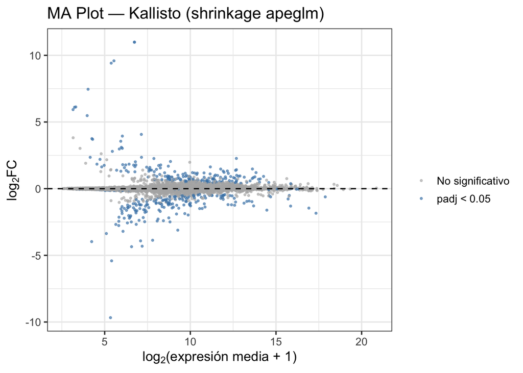

Figura 8. MA plot — Kallisto (shrinkage apeglm). Azul: genes significativos (padj < 0.05). Gris: no significativos. La línea horizontal en log2FC = 0 sirve de referencia: puntos equilibrados sobre y bajo la línea indican ausencia de sesgo sistemático.

```r
ma_k <- as.data.frame(res_kallisto_shrink) %>%
  mutate(
    significant  = !is.na(padj) & padj < 0.05,
    baseMean_log = log2(baseMean + 1)
  )

ggplot(ma_k, aes(x = baseMean_log, y = log2FoldChange, color = significant)) +
  geom_point(size = 0.6, alpha = 0.6) +
  scale_color_manual(values = c("FALSE" = "gray70", "TRUE" = "steelblue"),
                     labels = c("No significativo", "padj < 0.05")) +
  geom_hline(yintercept = 0, linetype = "dashed", color = "black") +
  labs(title = "MA Plot — Kallisto (shrinkage apeglm)",
       x     = expression("log"[2]*"(expresión media + 1)"),
       y     = expression("log"[2]*"FC"),
       color = "") +
  theme_bw(base_size = 13) +
  theme(plot.background = element_rect(fill = "white"))
```

**Interpretación:**Los puntos grises están centrados en log2FC = 0 a lo largo de todo el rango de expresión, confirmando que la normalización no introdujo sesgos sistemáticos. Los DEGs significativos (azul) se distribuyen tanto por encima como por debajo de la línea de referencia, consistente con el balance observado de ~57% down y ~43% up. La compresión de puntos hacia 0 en el extremo izquierdo (genes poco expresados) es el efecto esperado del shrinkage apeglm.

### 6.4 MA Plot y STAR

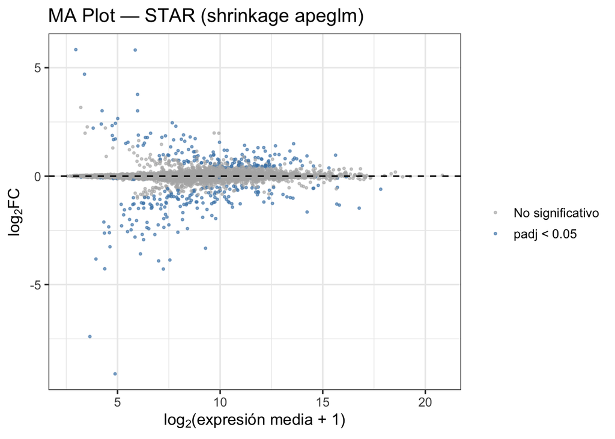

Figura 9. MA plot — STAR (shrinkage apeglm). Se esperan patrones similares a Kallisto. Diferencias en la densidad de puntos azules reflejan variaciones en el número de DEGs detectados por cada alineador.

```r
ma_s <- as.data.frame(res_star_shrink) %>%
  mutate(
    significant  = !is.na(padj) & padj < 0.05,
    baseMean_log = log2(baseMean + 1)
  )

ggplot(ma_s, aes(x = baseMean_log, y = log2FoldChange, color = significant)) +
  geom_point(size = 0.6, alpha = 0.6) +
  scale_color_manual(values = c("FALSE" = "gray70", "TRUE" = "steelblue"),
                     labels = c("No significativo", "padj < 0.05")) +
  geom_hline(yintercept = 0, linetype = "dashed", color = "black") +
  labs(title = "MA Plot — STAR (shrinkage apeglm)",
       x     = expression("log"[2]*"(expresión media + 1)"),
       y     = expression("log"[2]*"FC"),
       color = "") +
  theme_bw(base_size = 13) +
  theme(plot.background = element_rect(fill = "white"))
```

**Interpretación:**El patrón es prácticamente idéntico al de Kallisto, con DEGs distribuidos simétricamente alrededor de log2FC = 0 y la misma compresión en genes de baja expresión. La densidad ligeramente menor de puntos azules refleja los 37 DEGs menos detectados respecto a Kallisto, atribuible a diferencias en cómo cada alineador maneja lecturas multi-mapeo.

### 6.5 Heatmap y Top 20 DEGs (Kallisto)

El heatmap visualiza los patrones de expresión de los 20 genes con menor padj. Cada fila es un gen, cada columna es una muestra. Los colores representan la expresión estandarizada por fila (z-score dentro del heatmap): rojo = expresión alta relativa, azul = expresión baja relativa. El clustering jerárquico de filas y columnas se realiza de forma no supervisada — si las muestras del mismo genotipo se agrupan juntas, significa que los genes seleccionados realmente distinguen WT de Dp16.

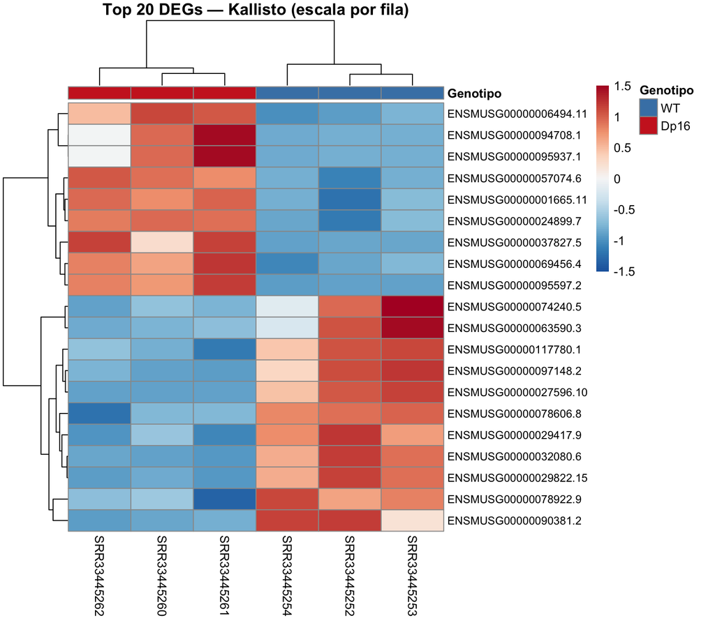

Figura 10. Heatmap de los 20 genes con menor padj — Kallisto (rlog, escalado por fila/z-score). La barra de color en la parte superior indica el genotipo de cada muestra. El clustering jerárquico es no supervisado.

```r
top_genes_k <- head(order(res_kallisto$padj, na.last = TRUE), 20)
mat_heat_k  <- assay(rld_kallisto)[top_genes_k, ]

ann_col    <- data.frame(Genotipo = metadata$genotype)
rownames(ann_col) <- rownames(metadata)
ann_colors <- list(Genotipo = c("WT" = "steelblue", "Dp16" = "firebrick3"))

pheatmap(mat_heat_k,
         cluster_rows      = TRUE,
         cluster_cols      = TRUE,
         show_rownames     = TRUE,
         show_colnames     = TRUE,
         annotation_col    = ann_col,
         annotation_colors = ann_colors,
         scale             = "row",
         color             = colorRampPalette(rev(brewer.pal(9, "RdBu")))(100),
         fontsize_row      = 9,
         main              = "Top 20 DEGs — Kallisto (escala por fila)")
```

**Interpretación:** El clustering jerárquico no supervisado agrupa correctamente las tres réplicas Dp16 (izquierda) separadas de las tres réplicas WT (derecha), sin que se le indique el genotipo. Esto confirma que los 20 genes más significativos son suficientes para distinguir ambos genotipos. Se observan dos bloques principales de genes: uno con expresión alta en Dp16 (rojo) que incluye ENSMUSG00000001665.11 y ENSMUSG00000006494.11, y otro con expresión baja en Dp16 (azul) que incluye ENSMUSG00000097148.2 y ENSMUSG00000117780.1.

### 6.6 Heatmap y Top 20 DEGs (STAR)

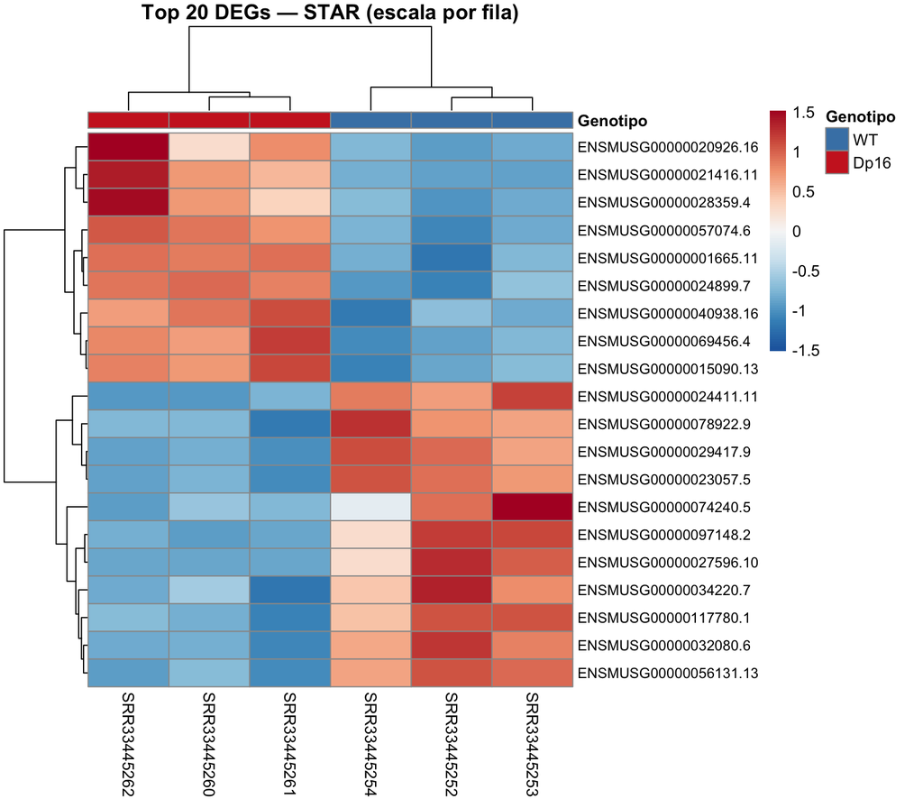

Figura 11. Heatmap de los 20 genes con menor padj — STAR (rlog, escalado por fila). La comparación con el heatmap de Kallisto (Figura 10) permite identificar genes consistentemente significativos en ambos alineadores.

```r
top_genes_s <- head(order(res_star$padj, na.last = TRUE), 20)
mat_heat_s  <- assay(rld_star)[top_genes_s, ]

pheatmap(mat_heat_s,
         cluster_rows      = TRUE,
         cluster_cols      = TRUE,
         show_rownames     = TRUE,
         show_colnames     = TRUE,
         annotation_col    = ann_col,
         annotation_colors = ann_colors,
         scale             = "row",
         color             = colorRampPalette(rev(brewer.pal(9, "RdBu")))(100),
         fontsize_row      = 9,
         main              = "Top 20 DEGs — STAR (escala por fila)")
```

**Interpretación:** El patrón de clustering es idéntico — Dp16 a la izquierda, WT a la derecha — y varios genes se repiten entre ambos top 20 (ENSMUSG00000001665.11, ENSMUSG00000069456.4, ENSMUSG00000029417.9, ENSMUSG00000074240.5), lo que los identifica como los candidatos más robustos del análisis.

## 7. Comparación Kallisto vs STAR

### 7.1 Genes compartidos y exclusivos

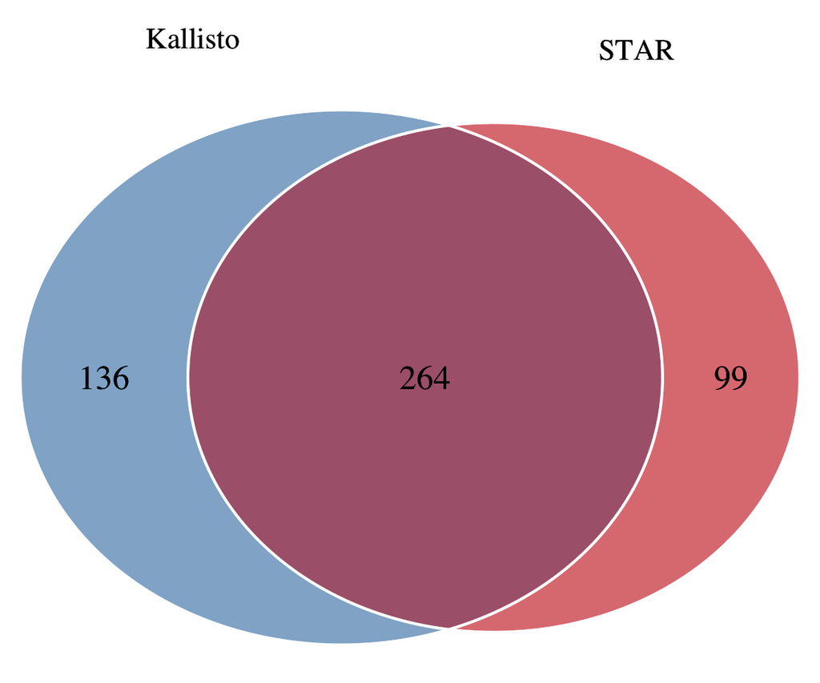

Figura 12. Diagrama de Venn: DEGs compartidos entre Kallisto y STAR (padj < 0.05). El área de intersección representa genes detectados como diferencialmente expresados por ambos alineadores.

```r
genes_kallisto <- rownames(sig_kallisto)
genes_star     <- rownames(sig_star)

genes_comunes <- intersect(genes_kallisto, genes_star)
genes_solo_k  <- setdiff(genes_kallisto, genes_star)
genes_solo_s  <- setdiff(genes_star, genes_kallisto)

venn.plot <- draw.pairwise.venn(
  area1      = length(genes_kallisto),
  area2      = length(genes_star),
  cross.area = length(genes_comunes),
  category   = c("Kallisto", "STAR"),
  fill       = c("steelblue", "firebrick3"),
  alpha      = 0.4,
  col        = "white",
  cex        = 1.5,
  cat.cex    = 1.3,
  cat.pos    = c(-20, 20),
  cat.dist   = 0.07
)
grid.draw(venn.plot)
```

```r
venn_resumen <- data.frame(
  Categoría = c("Solo Kallisto", "Compartidos", "Solo STAR"),
  N_genes   = c(length(genes_solo_k), length(genes_comunes), length(genes_solo_s))
)

kable(venn_resumen,
      caption = "Tabla 4. Distribución de DEGs entre alineadores (padj < 0.05).") %>%
  kable_styling(bootstrap_options = c("striped","hover","condensed"),
                full_width = FALSE)
```

Tabla 4. Distribución de DEGs entre alineadores (padj < 0.05).

| Categoría | N_genes |
| --- | --- |
| Solo Kallisto | 136 |
| Compartidos | 264 |
| Solo STAR | 99 |

## 8. Análisis Funcional y GO terms con gprofiler2

El análisis funcional convierte una lista de genes en significado biológico. gprofiler2 implementa una prueba hipergeométrica que evalúa si la proporción de genes de una categoría GO/KEGG/REAC en nuestra lista de DEGs es **mayor de lo esperado por azar** dado el universo de todos los genes analizados. Usamos los genes **compartidos entre Kallisto y STAR** para maximizar la confiabilidad biológica.

### 8.1 Preparar listas de genes

```r
# Genes compartidos entre alineadores, clasificados por dirección del cambio
up_genes   <- genes_comunes[sig_kallisto[genes_comunes, "log2FoldChange"] > 0]
down_genes <- genes_comunes[sig_kallisto[genes_comunes, "log2FoldChange"] < 0]

up_genes   <- up_genes[!is.na(up_genes)]
down_genes <- down_genes[!is.na(down_genes)]

# Remover número de versión de IDs Ensembl (ENSMUSG00000001234.5 → ENSMUSG00000001234)
up_genes   <- gsub("\\..*", "", up_genes)
down_genes <- gsub("\\..*", "", down_genes)

cat("Genes up-regulated (compartidos):", length(up_genes), "\n")
```

```
## Genes up-regulated (compartidos): 113
```

```r
cat("Genes down-regulated (compartidos):", length(down_genes), "\n")
```

```
## Genes down-regulated (compartidos): 151
```

```r
head(up_genes)
```

```
## [1] "ENSMUSG00000001665" "ENSMUSG00000002588" "ENSMUSG00000002847"
## [4] "ENSMUSG00000003477" "ENSMUSG00000005373" "ENSMUSG00000005677"
```

```r
head(down_genes)
```

```
## [1] "ENSMUSG00000000159" "ENSMUSG00000000303" "ENSMUSG00000000915"
## [4] "ENSMUSG00000001506" "ENSMUSG00000001763" "ENSMUSG00000002033"
```

**Interpretación:** De los 264 genes compartidos entre alineadores, 113 están sobreexpresados en Dp16 respecto a WT y 151 están reprimidos, manteniendo el balance observado en el análisis completo (~57% down, ~43% up). Los identificadores Ensembl fueron convertidos a formato sin versión (eliminando el sufijo numérico después del punto) para garantizar la compatibilidad con la base de datos de gprofiler2 para Mus musculus. Estas dos listas (genes up-regulated y down-regulated) se analizaron de forma independiente para identificar qué procesos biológicos se activan y cuáles se reprimen específicamente en el hígado del modelo Dp16.

### 8.2 Enriquecimiento con gprofiler2

```r
sources_db <- c("GO:BP", "GO:MF", "GO:CC", "KEGG", "REAC")

# multi_query = FALSE: devuelve una fila por término por query,
# con columnas normales: query, p_value, intersection_size, source, term_name.
# Con multi_query = TRUE esas columnas son listas y causan errores al filtrar.
multi_gp <- gost(
  query = list(
    "Up-regulated"   = up_genes,
    "Down-regulated" = down_genes
  ),
  organism          = "mmusculus",
  correction_method = "fdr",
  user_threshold    = 0.05,
  multi_query       = FALSE,
  ordered_query     = FALSE,
  sources           = sources_db,
  evcodes           = TRUE
)

cat("Columnas del resultado:", paste(colnames(multi_gp$result), collapse = ", "), "\n")
```

```
## Columnas del resultado: query, significant, p_value, term_size, query_size, intersection_size, precision, recall, term_id, source, term_name, effective_domain_size, source_order, parents, evidence_codes, intersection
```

```r
cat("Queries:", paste(unique(multi_gp$result$query), collapse = ", "), "\n")
```

```
## Queries: Down-regulated, Up-regulated
```

```r
cat("Términos enriquecidos totales:", nrow(multi_gp$result), "\n")
```

```
## Términos enriquecidos totales: 720
```

**Interpretación:** El análisis con gprofiler2 identificó 720 términos enriquecidos en total entre genes up-regulated y down-regulated (FDR < 0.05), distribuidos en cinco bases de datos: GO:BP, GO:MF, GO:CC, KEGG y REAC. El alto número de términos significativos refleja que los 264 genes compartidos, aunque representan una fracción pequeña del transcriptoma analizado, convergen en procesos biológicos bien definidos y estadísticamente sobre-representados en ambas direcciones de cambio.

### 8.3 Manhattan plot

El manhattan plot de gprofiler2 muestra todos los términos enriquecidos organizados por base de datos (color) y ordenados en el eje X. El eje Y es el -log10(FDR): puntos más altos = más significativos. Es útil para tener una visión panorámica de qué bases de datos están más enriquecidas y dónde se concentran los términos significativos.

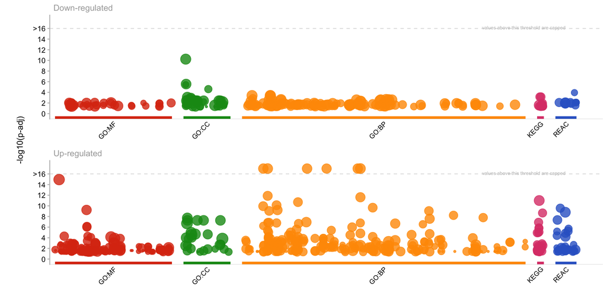

Figura 14. Manhattan plot de términos GO (BP, MF, CC), KEGG y REAC enriquecidos en los genes DEG compartidos (FDR < 0.05). Cada color representa una base de datos diferente.

```r
# gostplot() es la función nativa de gprofiler2 para este tipo de gráfico.
# Es la más robusta porque maneja internamente la estructura del objeto multi_gp.
gostplot(multi_gp, interactive = FALSE)
```

### 8.4 Top términos enriquecidos y Up-regulated

```r
if (!is.null(multi_gp$result)) {
  gost_df <- as.data.frame(multi_gp$result)

  bar_up <- gost_df %>%
    filter(query == "Up-regulated") %>%
    arrange(p_value) %>%
    head(20) %>%
    select(term_name, source, term_size, intersection_size, p_value) %>%
    mutate(p_value = formatC(p_value, format = "e", digits = 2))

  kable(bar_up,
        col.names = c("Término GO", "Base de datos", "Tamaño del término",
                      "Genes en overlap", "p-value (FDR)"),
        caption = "Tabla 5. Top 20 términos enriquecidos en genes up-regulated en Dp16 vs WT. 'Tamaño del término' indica cuántos genes del genoma pertenecen a esa categoría; 'Genes en overlap' es cuántos de nuestros DEGs caen en ella.") %>%
    kable_styling(bootstrap_options = c("striped","hover","condensed"),
                  full_width = FALSE)
}
```

Tabla 5. Top 20 términos enriquecidos en genes up-regulated en Dp16 vs WT. ‘Tamaño del término’ indica cuántos genes del genoma pertenecen a esa categoría; ‘Genes en overlap’ es cuántos de nuestros DEGs caen en ella.

| Término GO | Base de datos | Tamaño del término | Genes en overlap | p-value (FDR) |
| --- | --- | --- | --- | --- |
| small molecule metabolic process | GO:BP | 1549 | 44 | 1.54e-23 |
| lipid metabolic process | GO:BP | 1266 | 40 | 7.01e-23 |
| oxoacid metabolic process | GO:BP | 783 | 32 | 5.42e-21 |
| organic acid metabolic process | GO:BP | 789 | 32 | 5.42e-21 |
| carboxylic acid metabolic process | GO:BP | 769 | 30 | 4.36e-19 |
| monocarboxylic acid metabolic process | GO:BP | 549 | 26 | 2.46e-18 |
| catalytic activity | GO:MF | 5584 | 68 | 1.16e-15 |
| fatty acid metabolic process | GO:BP | 357 | 18 | 1.33e-12 |
| small molecule biosynthetic process | GO:BP | 500 | 20 | 2.43e-12 |
| Metabolic pathways | KEGG | 1646 | 40 | 1.00e-11 |
| organic acid biosynthetic process | GO:BP | 251 | 15 | 2.01e-11 |
| steroid metabolic process | GO:BP | 277 | 15 | 7.61e-11 |
| alcohol metabolic process | GO:BP | 287 | 15 | 1.16e-10 |
| carboxylic acid biosynthetic process | GO:BP | 247 | 14 | 2.21e-10 |
| Drug ADME | REAC | 105 | 13 | 2.79e-10 |
| oxidoreductase activity | GO:MF | 742 | 22 | 5.97e-10 |
| lipid biosynthetic process | GO:BP | 610 | 19 | 6.20e-10 |
| sulfur compound metabolic process | GO:BP | 224 | 13 | 9.03e-10 |
| monocarboxylic acid biosynthetic process | GO:BP | 176 | 12 | 9.03e-10 |
| Metabolism | REAC | 1740 | 39 | 1.61e-09 |

**Interpretación:** Los genes activados en Dp16 se enriquecen de forma masiva en procesos metabólicos hepáticos. Los dos términos más significativos “small molecule metabolic process” y “lipid metabolic process” tienen FDR de 1.54e-23 y 7.01e-23 respectivamente, valores extremadamente por encima del esperado por azar. El patrón es coherente a lo largo de los 20 términos: metabolismo y síntesis de lípidos, ácidos grasos, ácidos orgánicos y esteroides forman un bloque funcional activado en conjunto. El término “catalytic activity” de GO:MF (FDR 1.16e-15) con 68 genes en overlap indica que gran parte de los genes activados codifican enzimas metabólicas. Esto es directamente concordante con lo reportado por Dunn et al. (2026), que identifica disfunción del metabolismo lipídico y de ácidos biliares como el fenotipo hepático principal del modelo Dp16.

### 8.5 Top términos enriquecidos y Down-regulated

```r
if (!is.null(multi_gp$result)) {
  gost_df <- as.data.frame(multi_gp$result)

  bar_down <- gost_df %>%
    filter(query == "Down-regulated") %>%
    arrange(p_value) %>%
    head(20) %>%
    select(term_name, source, term_size, intersection_size, p_value) %>%
    mutate(p_value = formatC(p_value, format = "e", digits = 2))

  kable(bar_down,
        col.names = c("Término GO", "Base de datos", "Tamaño del término",
                      "Genes en overlap", "p-value (FDR)"),
        caption = "Tabla 6. Top 20 términos enriquecidos en genes down-regulated en Dp16 vs WT. Procesos reprimidos en el modelo de trisomía 16 respecto al ratón silvestre.") %>%
    kable_styling(bootstrap_options = c("striped","hover","condensed"),
                  full_width = FALSE)
}
```

Tabla 6. Top 20 términos enriquecidos en genes down-regulated en Dp16 vs WT. Procesos reprimidos en el modelo de trisomía 16 respecto al ratón silvestre.

| Término GO | Base de datos | Tamaño del término | Genes en overlap | p-value (FDR) |
| --- | --- | --- | --- | --- |
| extracellular region | GO:CC | 2340 | 44 | 5.80e-11 |
| extracellular space | GO:CC | 1136 | 24 | 2.79e-06 |
| membrane attack complex | GO:CC | 7 | 4 | 3.55e-06 |
| pore complex | GO:CC | 26 | 5 | 2.49e-05 |
| Terminal pathway of complement | REAC | 8 | 4 | 1.14e-04 |
| immune system process | GO:BP | 2557 | 33 | 4.06e-04 |
| defense response | GO:BP | 1633 | 25 | 4.06e-04 |
| response to stress | GO:BP | 3596 | 41 | 4.06e-04 |
| immune response | GO:BP | 1726 | 26 | 4.06e-04 |
| PPAR signaling pathway | KEGG | 89 | 7 | 7.17e-04 |
| Complement and coagulation cascades | KEGG | 94 | 7 | 7.17e-04 |
| endoplasmic reticulum | GO:CC | 1758 | 25 | 8.25e-04 |
| cell surface | GO:CC | 753 | 15 | 1.13e-03 |
| humoral immune response mediated by circulating immunoglobulin | GO:BP | 43 | 5 | 1.32e-03 |
| endomembrane system | GO:CC | 4005 | 41 | 2.22e-03 |
| response to external stimulus | GO:BP | 2346 | 29 | 2.27e-03 |
| response to stimulus | GO:BP | 9759 | 74 | 2.49e-03 |
| positive regulation of response to stimulus | GO:BP | 2034 | 26 | 2.49e-03 |
| response to other organism | GO:BP | 1566 | 22 | 2.49e-03 |
| response to external biotic stimulus | GO:BP | 1570 | 22 | 2.49e-03 |

**Interpretación:** Los genes reprimidos en Dp16 muestran dos patrones distintos en la tabla. El término más significativo es “extracellular region” de GO:CC (FDR 5.80e-11, 44 genes en overlap), seguido de “extracellular space” y “membrane attack complex” lo que indica que los genes reprimidos codifican principalmente proteínas secretadas o de la matriz extracelular. El segundo patrón es inmune: “immune system process”, “defense response”, “immune response” y “response to stress” comparten el mismo FDR (4.06e-04), y la presencia de “Terminal pathway of complement” en REAC y “Complement and coagulation cascades” en KEGG apunta específicamente a la represión de la cascada del complemento en el hígado Dp16.

Comparado con los términos up-regulated, los FDR son considerablemente menos extremos (máximo 5.80e-11 vs 1.54e-23), lo que indica que la señal metabólica activada es estadísticamente más robusta que la señal de represión. Esto es consistente con lo reportado por Dunn et al. (2026), que describe disfunción metabólica e inflamación como los fenotipos dominantes del hígado Dp16.

### 8.6 Barplot GO:BP y Up-regulated

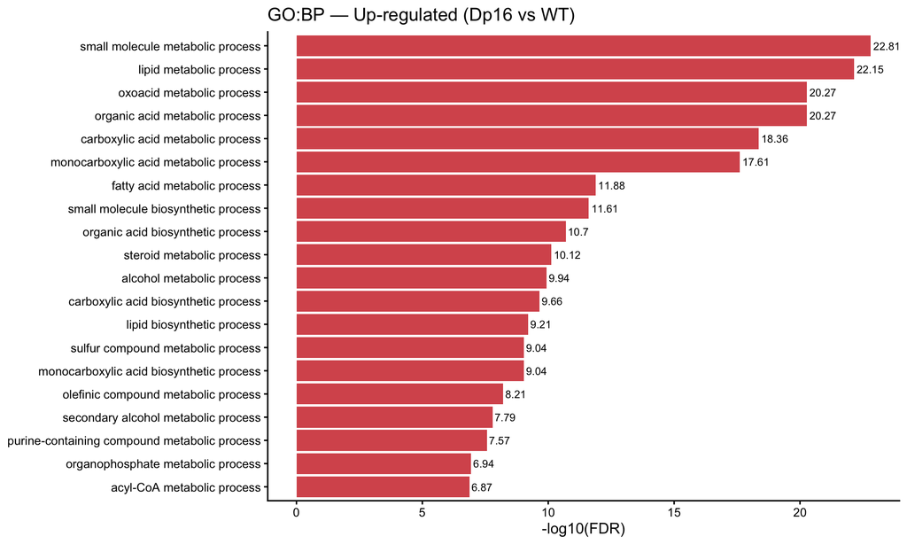

Figura 15. Top 20 procesos biológicos (GO:BP) enriquecidos en genes up-regulated en Dp16 vs WT. El eje X muestra la significancia en escala -log10(FDR): barras más largas = mayor enriquecimiento.

```r
if (!is.null(multi_gp$result)) {
  gost_df <- as.data.frame(multi_gp$result)

  bar_up_plot <- gost_df %>%
    filter(query == "Up-regulated", source == "GO:BP") %>%
    arrange(p_value) %>%
    head(20) %>%
    mutate(log10p = round(-log10(p_value), 2),
           num    = seq_len(n()))

  if (nrow(bar_up_plot) > 0) {
    ggplot(bar_up_plot,
           aes(x = log10p, y = reorder(term_name, log10p))) +
      geom_bar(stat = "identity", fill = "firebrick3", alpha = 0.8) +
      geom_text(aes(label = log10p), hjust = -0.1, size = 3) +
      labs(title = "GO:BP — Up-regulated (Dp16 vs WT)",
           x = "-log10(FDR)", y = NULL) +
      theme_classic(base_size = 12) +
      theme(plot.background = element_rect(fill = "white"))
  }
}
```

**Interpretación:** Los 20 procesos GO:BP más enriquecidos en genes up-regulated forman un bloque funcional coherente centrado en el metabolismo hepático. Los seis términos más significativos metabolismo de pequeñas moléculas, lípidos, oxoácidos, ácidos orgánicos, ácidos carboxílicos y ácidos monocarboxílicos todos superan -log10(FDR) de 17, indicando una activación masiva y coordinada de la maquinaria metabólica. La presencia de “fatty acid metabolic process”, “steroid metabolic process” y “acyl-CoA metabolic process” en los últimos puestos confirma que la activación no es de un solo proceso sino de toda la red metabólica hepática. Esto es directamente concordante con lo reportado por Dunn et al. (2026).

### 8.7 Barplot GO:BP — Down-regulated

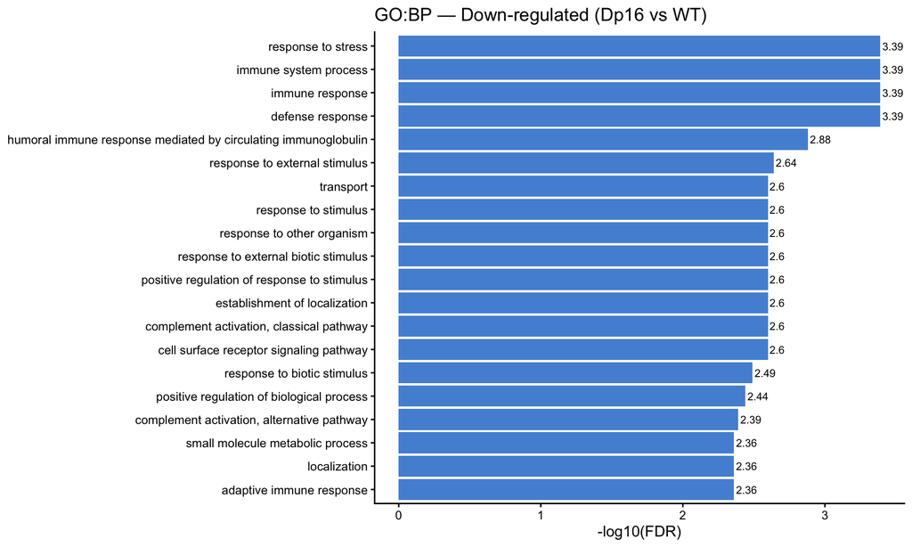

Figura 16. Top 20 procesos biológicos (GO:BP) enriquecidos en genes down-regulated en Dp16 vs WT. Procesos represados en el modelo de trisomía, ordenados por significancia.

```r
if (!is.null(multi_gp$result)) {
  gost_df <- as.data.frame(multi_gp$result)

  bar_down_plot <- gost_df %>%
    filter(query == "Down-regulated", source == "GO:BP") %>%
    arrange(p_value) %>%
    head(20) %>%
    mutate(log10p = round(-log10(p_value), 2),
           num    = seq_len(n()))

  if (nrow(bar_down_plot) > 0) {
    ggplot(bar_down_plot,
           aes(x = log10p, y = reorder(term_name, log10p))) +
      geom_bar(stat = "identity", fill = "dodgerblue3", alpha = 0.8) +
      geom_text(aes(label = log10p), hjust = -0.1, size = 3) +
      labs(title = "GO:BP — Down-regulated (Dp16 vs WT)",
           x = "-log10(FDR)", y = NULL) +
      theme_classic(base_size = 12) +
      theme(plot.background = element_rect(fill = "white"))
  }
}
```

**Interpretación:** Los procesos GO:BP reprimidos en Dp16 se concentran en respuesta inmune y defensa. Los cuatro términos más significativos “response to stress”, “immune system process”, “immune response” y “defense response” comparten exactamente el mismo FDR (-log10 = 3.39), lo que indica que forman un bloque co-reprimido. La presencia de “complement activation” por vía clásica y alternativa, y “humoral immune response mediated by circulating immunoglobulin” apunta específicamente a la represión de la inmunidad humoral en el hígado Dp16. Comparando ambas figuras, la escala es muy diferente: el máximo en down-regulated es 3.39 vs 22.81 en up-regulated, lo que refleja que la activación metabólica es el fenotipo dominante y estadísticamente más robusto en el hígado Dp16.

## 9. Guardar resultados

```r
if (!dir.exists(figdir)) dir.create(figdir, recursive = TRUE)

# Resultados DEG completos (con shrinkage apeglm)
write.csv(as.data.frame(res_kallisto_shrink),
          file = paste0(outdir, "DESeq2_kallisto_results.csv"))
write.csv(as.data.frame(res_star_shrink),
          file = paste0(outdir, "DESeq2_STAR_results.csv"))

# Solo genes significativos (padj < 0.05)
write.csv(sig_kallisto,
          file = paste0(outdir, "DESeq2_kallisto_significant.csv"))
write.csv(sig_star,
          file = paste0(outdir, "DESeq2_STAR_significant.csv"))

# Resultados GO terms
if (!is.null(multi_gp$result)) {
  gost_export <- multi_gp$result
  # Convertir columnas tipo lista a texto para exportar en CSV
  gost_export$parents        <- sapply(gost_export$parents, paste, collapse = ";")
  gost_export$evidence_codes <- sapply(gost_export$evidence_codes, paste, collapse = ";")
  write.csv(gost_export,
            file      = paste0(outdir, "GOterms_gprofiler2_results.csv"),
            row.names = FALSE)
}

# Objetos R: dds, vsd, resultados, z-score, melted counts
save(dds, dds_star,
     rld_kallisto, rld_star,
     res_kallisto_shrink, res_star_shrink,
     zscore_mat, melted_norm_counts,
     file = paste0(outdir, "DEG_objects.RData"))

cat("Todos los archivos guardados en:", outdir, "\n")
```

```
## Todos los archivos guardados en: /Users/dubsirubs/Desktop/RNAseq_Equipo4/results_final/
```

## 10. Conclusiones

*Documento generado con R Markdown.*  
*Análisis realizado en el cluster `ken.lavis.unam.mx`*  
*Ruta del proyecto: `/Users/dubsirubs/Desktop/RNAseq_Equipo4/` y `/mnt/data/bioinfo-estadistica-2/RNAseq_2026/equipos/Equipo4/`*